# SIAMCAT input files formats

Konrad Zych, Jakob Wirbel, and Georg Zeller

EMBL Heidelberg

georg.zeller@embl.de

Date last modified: 2018-09-24

# 1 Introduction

This vignette illustrates how to read and input your own data to the `SIAMCAT` package. We will cover reading in text files from the disk, formatting them and using them to create an object of `siamcat-class`.

The `siamcat-class` is the centerpiece of the package. All of the input data and result are stored inside of it. The structure of the object is described below in the siamcat-class object section.

# 2 Loading your data into R

## 2.1 SIAMCAT input

Generally, there are three types of input for `SIAMCAT`:

### 2.1.1 Features

The features should be a `matrix`, a `data.frame`, or an `otu_table`, organized as follows:

`features (in rows) x samples (in columns).`

|  | Sample_1 | Sample_2 | Sample_3 | Sample_4 | Sample_5 |
| --- | --- | --- | --- | --- | --- |
| **Feature_1** | 0.59 | 0.71 | 0.78 | 0.61 | 0.66 |
| **Feature_2** | 0.00 | 0.02 | 0.00 | 0.00 | 0.00 |
| **Feature_3** | 0.02 | 0.00 | 0.00 | 0.00 | 0.20 |
| **Feature_4** | 0.34 | 0.00 | 0.13 | 0.07 | 0.00 |
| **Feature_5** | 0.06 | 0.16 | 0.00 | 0.00 | 0.00 |

> Please note that `SIAMCAT` is supposed to work with **relative abundances**. Other types of data (e.g. counts) will also work, but not all functions of the package will result in meaningful outputs.

An example of a typical feature file is attached to the `SIAMCAT` package, containing data from a publication investigating the microbiome in colorectal cancer (CRC) patients and controls (the study can be found here: [Zeller et al](http://europepmc.org/abstract/MED/25432777)). The metagenomics data were processed with the [MOCAT](http://mocat.embl.de/) pipeline, returning taxonomic profiles on the species levels (`specI`):

```r
library(SIAMCAT)
fn.in.feat  <- system.file(
    "extdata",
    "feat_crc_zeller_msb_mocat_specI.tsv",
    package = "SIAMCAT"
)
```

One way to load such data into `R` could be the use of `read.table`

*(Beware of the defaults in R! They are not always useful…)*

```r
feat <- read.table(fn.in.feat, sep='\t',
    header=TRUE, quote='',
    stringsAsFactors = FALSE, check.names = FALSE)
# look at some features
feat[110:114, 1:2]
```

```
##                                CCIS27304052ST-3-0 CCIS15794887ST-4-0
## Bacteroides caccae [h:1096]          1.557937e-03       1.761949e-03
## Bacteroides eggerthii [h:1097]       2.734527e-05       4.146882e-05
## Bacteroides stercoris [h:1098]       1.173786e-03       2.475838e-03
## Bacteroides clarus [h:1099]          4.830533e-04       4.589747e-06
## Methanohalophilus mahii [h:11]       0.000000e+00       0.000000e+00
```

### 2.1.2 Metadata

The metadata should be either a matrix or a `data.frame`.

`samples (in rows) x metadata (in columns)`:

|  | Age | Gender | BMI |
| --- | --- | --- | --- |
| **Sample_1** | 52 | 1 | 20 |
| **Sample_2** | 37 | 1 | 18 |
| **Sample_3** | 66 | 2 | 24 |
| **Sample_4** | 54 | 2 | 26 |
| **Sample_5** | 65 | 2 | 30 |

The `rownames` of the metadata should match the `colnames` of the feature matrix.

Again, an example of such a file is attached to the `SIAMCAT` package, taken from the same study:

```r
fn.in.meta  <- system.file(
    "extdata",
    "num_metadata_crc_zeller_msb_mocat_specI.tsv",
    package = "SIAMCAT"
)
```

Also here, the `read.table` can be used to load the data into `R`.

```r
meta <- read.table(fn.in.meta, sep='\t',
    header=TRUE, quote='',
    stringsAsFactors = FALSE, check.names = FALSE)
head(meta)
```

```
##                    age gender bmi diagnosis localization crc_stage fobt
## CCIS27304052ST-3-0  52      1  20         0           NA         0    0
## CCIS15794887ST-4-0  37      1  18         0           NA         0    0
## CCIS74726977ST-3-0  66      2  24         1           NA         0    0
## CCIS16561622ST-4-0  54      2  26         0           NA         0    0
## CCIS79210440ST-3-0  65      2  30         0           NA         0    1
## CCIS82507866ST-3-0  57      2  24         0           NA         0    0
##                    wif_test
## CCIS27304052ST-3-0        0
## CCIS15794887ST-4-0        0
## CCIS74726977ST-3-0       NA
## CCIS16561622ST-4-0        0
## CCIS79210440ST-3-0        0
## CCIS82507866ST-3-0        0
```

### 2.1.3 Label

Finally, the label can come in different three different flavours:

- **Named vector**: A named vector containing information about cases and controls. The names of the vector should match the `rownames` of the metadata and the `colnames` of the feature data. The label can contain either the information about cases and controls either
  - as integers (e.g. `0` and `1`),
  - as characters (e.g. `CTR` and `IBD`), or
  - as factors.
- **Metadata column**: You can provide the name of a column in the metadata for the creation of the label. See below for an example.
- **Label file**: `SIAMCAT` has a function called `read.label`, which will create a label object from a label file. The file should be organized as follows:
  - The first line is supposed to read: `#BINARY:1=[label for cases];-1=[label for controls]`
  - The second row should contain the sample identifiers as tab-separated list (consistent with feature and metadata).
  - The third row is then supposed to contain the actual class labels (tab-separated): `1` for each case and `-1` for each control.

  An example file is attached to the package again, if you want to have a look at it.

For our example dataset, we can create the label object out of the metadata column called `diagnosis`:

```r
label <- create.label(meta=meta, label="diagnosis",
    case = 1, control=0)
```

When we later plot the results, it might be nicer to have names for the different groups stored in the label object (instead of `1` and `0`). We can also supply them to the `create.label` function:

```r
label <- create.label(meta=meta, label="diagnosis",
    case = 1, control=0,
    p.lab = 'cancer', n.lab = 'healthy')
```

```
## Label used as case:
##    1
## Label used as control:
##    0
```

```
## + finished create.label.from.metadata in    0 s
```

```r
label$info
```

```
## healthy  cancer
##      -1       1
```

> Note:  
> If you have no label information for your dataset, you can still create a `SIAMCAT` object from your features alone. The `SIAMCAT` object without label information will contain a `TEST` label that can be used for making holdout predictions. Other functions, e.g. model training, will not work on such an object.

## 2.2 LEfSe format files

[LEfSe](https://bitbucket.org/biobakery/biobakery/wiki/lefse) is a tool for identification of associations between micriobial features and up to two metadata. LEfSe uses LDA (linear discriminant analysis).

LEfSe input file is a `.tsv` file. The first few rows contain the metadata. The following row contains sample names and the rest of the rows are occupied by features. The first column holds the row names:

| label | healthy | healthy | healthy | cancer | cancer |
| --- | --- | --- | --- | --- | --- |
| **age** | 52 | 37 | 66 | 54 | 65 |
| **gender** | 1 | 1 | 2 | 2 | 2 |
| **Sample_info** | Sample_1 | Sample_2 | Sample_3 | Sample_4 | Sample_5 |
| **Feature_1** | 0.59 | 0.71 | 0.78 | 0.61 | 0.66 |
| **Feature_2** | 0.00 | 0.02 | 0.00 | 0.00 | 0.00 |
| **Feature_3** | 0.02 | 0.00 | 0.00 | 0.00 | 0.00 |
| **Feature_4** | 0.34 | 0.00 | 0.43 | 0.00 | 0.00 |
| **Feature_5** | 0.56 | 0.56 | 0.00 | 0.00 | 0.00 |

An example of such a file is attached to the `SIAMCAT` package:

```r
fn.in.lefse<- system.file(
    "extdata",
    "LEfSe_crc_zeller_msb_mocat_specI.tsv",
    package = "SIAMCAT"
)
```

`SIAMCAT` has a dedicated function to read LEfSe format files. The `read.lefse` function will read in the input file and extract metadata and features:

```r
meta.and.features <- read.lefse(fn.in.lefse,
    rows.meta = 1:6, row.samples = 7)
meta <- meta.and.features$meta
feat <- meta.and.features$feat
```

We can then create a label object from one of the columns of the meta object and create a `siamcat` object:

```r
label <- create.label(meta=meta, label="label", case = "cancer")
```

```
## Label used as case:
##    cancer
## Label used as control:
##    healthy
```

```
## + finished create.label.from.metadata in 0.01 s
```

## 2.3 metagenomeSeq format files

[metagenomeSeq](http://bioconductor.org/packages/metagenomeSeq/) is an R package to determine differentially abundant features between multiple samples.

There are two ways to input data into metagenomeSeq:

1. two files, one for metadata and one for features - those can be used in `SIAMCAT` just like described in SIAMCAT input with `read.table`:

```r
fn.in.feat  <- system.file(
    "extdata",
    "CHK_NAME.otus.count.csv",
    package = "metagenomeSeq"
)
feat <- read.table(fn.in.feat, sep='\t',
    header=TRUE, quote='', row.names = 1,
    stringsAsFactors = FALSE, check.names = FALSE
)
```

2. `BIOM` format file, that can be used in `SIAMCAT` as described in the following section

## 2.4 BIOM format files

The BIOM format files can be added to `SIAMCAT` via `phyloseq`. First the file should be imported using the `phyloseq` function `import_biom`. Then a `phyloseq` object can be imported as a `siamcat` object as descibed in the next section.

## 2.5 Creating a siamcat object of a phyloseq object

The `siamcat` object extends on the `phyloseq` object. Therefore, creating a `siamcat` object from a `phyloseq` object is really straightforward. This can be done with the `siamcat` constructor function. First, however, we need to create a label object:

```r
data("GlobalPatterns") ## phyloseq example data
label <- create.label(meta=sample_data(GlobalPatterns),
    label = "SampleType",
    case = c("Freshwater", "Freshwater (creek)", "Ocean"))
```

```
## Label used as case:
##    Freshwater,Freshwater (creek),Ocean
## Label used as control:
##    rest
```

```
## + finished create.label.from.metadata in 0.02 s
```

```r
# run the constructor function
siamcat <- siamcat(phyloseq=GlobalPatterns, label=label)
```

```
## + starting validate.data
```

```
## +++ checking overlap between labels and features
```

```
## + Keeping labels of 26 sample(s).
```

```
## +++ checking sample number per class
```

```
## Data set has a limited number of training examples:
##  rest    18
##  Case    8
## Note that a dataset this small/skewed is not necessarily suitable for analysis in this pipeline.
```

```
## +++ checking overlap between samples and metadata
```

```
## + finished validate.data in 0.98 s
```

# 3 Creating a siamcat-class object

The `siamcat-class` is the centerpiece of the package. All of the is stored inside of the object:

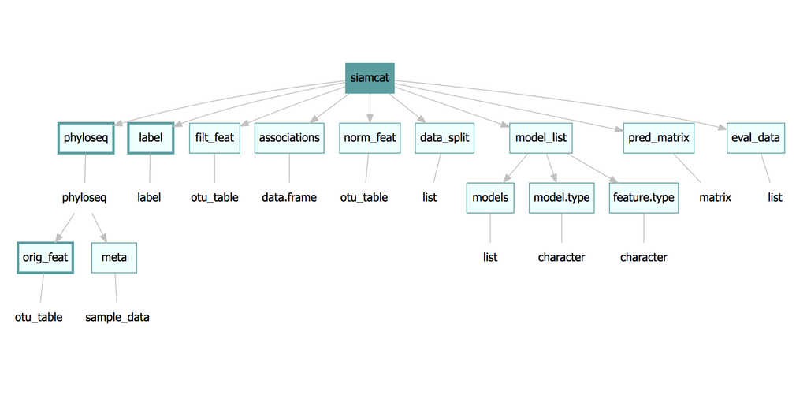

In the figure above, rectangles depict slots of the object and the class of the object stored in the slot is given in the ovals. There are two obligatory slots -**phyloseq** (containing the metadata as `sample_data` and the original features as `otu_table`) and **label** - marked with thick borders.

The `siamcat` object is constructed using the `siamcat()` function. There are two ways to initialize it:

- **Features**: You can provide a feature `matrix`, `data.frame`, or `otu_table` to the function (together with label and metadata information):

  ```r
  siamcat <- siamcat(feat=feat, label=label, meta=meta)
  ```

- **phyloseq**: The alternative is to create a `siamcat` object directly out of a `phyloseq` object:

  ```r
  siamcat <- siamcat(phyloseq=phyloseq, label=label)
  ```

Please note that you **have to** provide either `feat` or `phyloseq` and that you **cannot** provide both.

In order to explain the `siamcat` object better we will show how each of the slots is filled.

## 3.1 phyloseq, label and orig_feat slots

The phyloseq and label slots are obligatory.

- The phyloseq slot is an object of class `phyloseq`, which is described in the help file of the `phyloseq` class. Help can be accessed by typing into R console: `help('phyloseq-class')`.
  - The `otu_table` slot in `phyloseq` -see `help('otu_table-class')`- stores the original feature table. For `SIAMCAT`, this slot can be accessed by `orig_feat`.
- The label slot contains a list. This list has a specific set of entries -see `help('label-class')`- that are automatically generated by the `read.label` or `create.label` functions.

The `phyloseq`, label and orig_feat are filled when the `siamcat` object is first created with the constructor function.

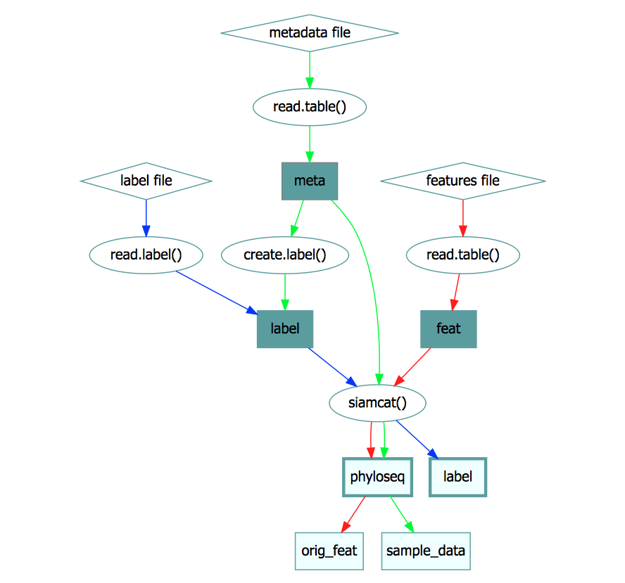

## 3.2 All the other slots

Other slots are filled during the run of the `SIAMCAT` workflow:

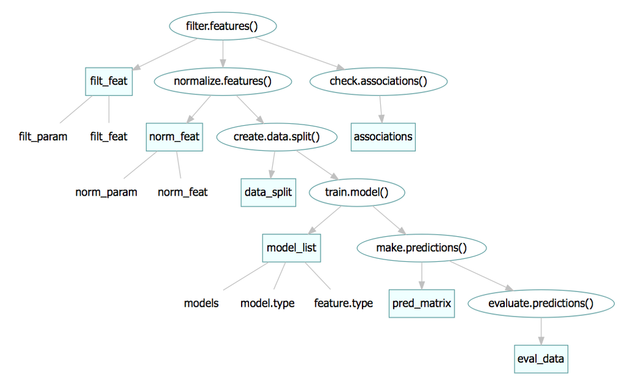

## 3.3 Accessing and assigning slots

Each slot in `siamcat` can be accessed by typing

```
slot_name(siamcat)
```

e.g. for the `eval_data` slot you can types

```r
eval_data(siamcat)
```

There is one notable exception: the phyloseq slot has to be accessed with `physeq(siamcat)` due to technical reasons.

Slots will be filled during the `SIAMCAT` workflow by the package’s functions. However, if for any reason a slot needs to be assigned outside of the workflow, the following formula can be used:

```
slot_name(siamcat) <- object_to_assign
```

e.g. to assign a `new_label` object to the `label` slot:

```r
label(siamcat) <- new_label
```

*Please note that this may lead to unforeseen consequences…*

## 3.4 Slots inside the slots

There are two slots that have slots inside of them. First, the `model_list` slot has a `models` slot that contains the actual list of [mlr](https://mlr-org.github.io/mlr-tutorial/devel/html/index.html) models -can be accessed via `models(siamcat)`- and `model.type` which is a character with the name of the method used to train the model: `model_type(siamcat)`.

The phyloseq slot has a complex structure. However, unless the phyloseq object is created outside of the `SIAMCAT` workflow, only two slots of phyloseq slot will be occupied: the `otu_table` slot containing the features table and the `sam_data` slot containing metadata information. Both can be accessed by typing either `features(siamcat)` or `meta(siamcat)`.

Additional slots inside the phyloseq slots do not have dedicated accessors, but can easily be reached once the phyloseq object is exported from the `siamcat` object:

```r
phyloseq <- physeq(siamcat)
tax_tab <- tax_table(phyloseq)
head(tax_tab)
```

```
## Taxonomy Table:     [6 taxa by 7 taxonomic ranks]:
##        Kingdom   Phylum          Class          Order          Family
## 549322 "Archaea" "Crenarchaeota" "Thermoprotei" NA             NA
## 522457 "Archaea" "Crenarchaeota" "Thermoprotei" NA             NA
## 951    "Archaea" "Crenarchaeota" "Thermoprotei" "Sulfolobales" "Sulfolobaceae"
## 244423 "Archaea" "Crenarchaeota" "Sd-NA"        NA             NA
## 586076 "Archaea" "Crenarchaeota" "Sd-NA"        NA             NA
## 246140 "Archaea" "Crenarchaeota" "Sd-NA"        NA             NA
##        Genus        Species
## 549322 NA           NA
## 522457 NA           NA
## 951    "Sulfolobus" "Sulfolobusacidocaldarius"
## 244423 NA           NA
## 586076 NA           NA
## 246140 NA           NA
```

If you want to find out more about the phyloseq data structure, head over to the [phyloseq](https://bioconductor.org/packages/release/bioc/html/phyloseq.html) BioConductor page. # Session Info

[session information not shown]